# BNFO667 Final - Lung Cancer Prediction

## Check if random forest is better

## Random Forest

```r
library(randomForest)
```

```r
set.seed(123)
rf <- randomForest(Level~.,data=train_data)
rf
```

```
#>
#> Call:
#>  randomForest(formula = Level ~ ., data = train_data)
#>                Type of random forest: classification
#>                      Number of trees: 500
#> No. of variables tried at each split: 4
#>
#>         OOB estimate of  error rate: 0%
#> Confusion matrix:
#>        High Low Medium class.error
#> High    248   0      0           0
#> Low       0 216      0           0
#> Medium    0   0    236           0
```

- The random forest model trained on the training data seems to perform very well with an OOB error rate of 0% and perfect confusion matrix on the training data.

Using random forest to make predictions on the test data:

```r
# Make predictions on the test data
pred <- predict(rf, newdata = test_data)
# Evaluate the performance of the model
confusionMatrix(pred, test_data$Level)
```

```
#> Confusion Matrix and Statistics
#>
#>           Reference
#> Prediction High Low Medium
#>     High    117   0      0
#>     Low       0  87      0
#>     Medium    0   0     96
#>
#> Overall Statistics
#>
#>                Accuracy : 1
#>                  95% CI : (0.9878, 1)
#>     No Information Rate : 0.39
#>     P-Value [Acc > NIR] : < 2.2e-16
#>
#>                   Kappa : 1
#>
#>  Mcnemar's Test P-Value : NA
#>
#> Statistics by Class:
#>
#>                      Class: High Class: Low Class: Medium
#> Sensitivity                 1.00       1.00          1.00
#> Specificity                 1.00       1.00          1.00
#> Pos Pred Value              1.00       1.00          1.00
#> Neg Pred Value              1.00       1.00          1.00
#> Prevalence                  0.39       0.29          0.32
#> Detection Rate              0.39       0.29          0.32
#> Detection Prevalence        0.39       0.29          0.32
#> Balanced Accuracy           1.00       1.00          1.00
```

- The random forest model appears to have achieved perfect accuracy on the test data!!
- with an overall accuracy of 1 and perfect sensitivities and specificities for each class.
- It’s important to note that this may be an overfitting issue, especially given the perfect OOB estimate of 0% error rate.
- This could be the limited size of the dataset, which may lead to overfitting in complex models such as random forests.
- It would be ideal to see the model’s performance on new data from a larger dataset

So far, the models have shown us that obesity, air pollution, balanced diet, cough of blood, passive smoker are all strongly correlated with lung cancer - balanced diet is a very odd attirbute that could lead to lung cancer.

Additionally, the Random Forest model performed slightly better than the penalized logistic regression, with <0.01 more accuracy.

## K-nearest neighbors (KNN)

```r
library(class)
library(dplyr)
as.numeric(train_data$Level)
as.numeric(test_data$Level)
train_data1 <- mutate_all(train_data[,-24], function(x) as.numeric(as.character(x)))
test_data1 <- mutate_all(test_data[,-24], function(x) as.numeric(as.character(x)))
```

```r
cbind(train_data1, train_data$Level)
cbind(test_data1, test_data$Level)
```

```r
k <- 5 # number of neighbors to consider
pred1 <- knn(train_data1, test_data1, train_data$Level, k)

confusionMatrix(pred1, test_data$Level)
```

```
#> Confusion Matrix and Statistics
#>
#>           Reference
#> Prediction High Low Medium
#>     High    117   0      0
#>     Low       0  86      0
#>     Medium    0   1     96
#>
#> Overall Statistics
#>
#>                Accuracy : 0.9967
#>                  95% CI : (0.9816, 0.9999)
#>     No Information Rate : 0.39
#>     P-Value [Acc > NIR] : < 2.2e-16
#>
#>                   Kappa : 0.995
#>
#>  Mcnemar's Test P-Value : NA
#>
#> Statistics by Class:
#>
#>                      Class: High Class: Low Class: Medium
#> Sensitivity                 1.00     0.9885        1.0000
#> Specificity                 1.00     1.0000        0.9951
#> Pos Pred Value              1.00     1.0000        0.9897
#> Neg Pred Value              1.00     0.9953        1.0000
#> Prevalence                  0.39     0.2900        0.3200
#> Detection Rate              0.39     0.2867        0.3200
#> Detection Prevalence        0.39     0.2867        0.3233
#> Balanced Accuracy           1.00     0.9943        0.9975
```

- the k-nearest neighbors model performs very well on this data with an accuracy of 0.9967. The model correctly predicts the high-risk patients with a sensitivity of 1.00 and the low-risk patients with a specificity of 1.00. The model also correctly predicts the medium-risk patients with a sensitivity of 1.0000 and a positive predictive value of 0.9897.
- Overall, this model performed the same as the penalized logistic regression and slightly worse than the random forest

## Unsupervised Methods

- Unsupervised learning methods are used when there is no labeled data available, and the goal is to discover patterns and structure in the data.
- In the case of predicting lung cancer, unsupervised learning methods can be used to identify groups of patients with similar characteristics or to identify features that are most strongly associated with lung cancer.

## PCA dimensionality reduction

- finding the linear combinations of the features that explain the maximum variance in the data
- develop a better understanding of the factors that contribute to lung cancer and potentially inform future predictive models
  - can’t really predict lung cancer directly

```r
library(factoextra)
# Extract features
df<- data[,-26]
df<- data[,-1:-2]
```

```r
#remove patien ID, index, and level
features <- df[,-24]
```

```r
# Perform PCA
pca <- princomp(features)

# View summary of PCA results
summary(pca)
```

```
#> Importance of components:
#>                            Comp.1    Comp.2     Comp.3     Comp.4     Comp.5
#> Standard deviation     12.0290208 6.6145720 3.68669135 2.96862282 2.62233723
#> Proportion of Variance  0.5954225 0.1800397 0.05592915 0.03626392 0.02829709
#> Cumulative Proportion   0.5954225 0.7754622 0.83139131 0.86765523 0.89595232
#>                            Comp.6     Comp.7     Comp.8     Comp.9     Comp.10
#> Standard deviation     2.27881580 1.69871381 1.64569142 1.58819183 1.535353382
#> Proportion of Variance 0.02136895 0.01187422 0.01114452 0.01037936 0.009700216
#> Cumulative Proportion  0.91732126 0.92919549 0.94034001 0.95071937 0.960419585
#>                            Comp.11     Comp.12    Comp.13     Comp.14
#> Standard deviation     1.392201272 1.156915931 1.12556422 1.048734884
#> Proportion of Variance 0.007975699 0.005507675 0.00521321 0.004525808
#> Cumulative Proportion  0.968395283 0.973902958 0.97911617 0.983641976
#>                            Comp.15     Comp.16     Comp.17     Comp.18
#> Standard deviation     1.005767926 0.860173411 0.759914139 0.692400541
#> Proportion of Variance 0.004162558 0.003044645 0.002376259 0.001972784
#> Cumulative Proportion  0.987804534 0.990849179 0.993225438 0.995198222
#>                            Comp.19     Comp.20      Comp.21      Comp.22
#> Standard deviation     0.620004824 0.574614169 0.4316550447 0.3890259314
#> Proportion of Variance 0.001581812 0.001358681 0.0007667227 0.0006227615
#> Cumulative Proportion  0.996780033 0.998138714 0.9989054366 0.9995281981
#>                             Comp.23
#> Standard deviation     0.3386082068
#> Proportion of Variance 0.0004718019
#> Cumulative Proportion  1.0000000000
```

```r
pca
```

```
#> Call:
#> princomp(x = features)
#>
#> Standard deviations:
#>     Comp.1     Comp.2     Comp.3     Comp.4     Comp.5     Comp.6     Comp.7
#> 12.0290208  6.6145720  3.6866914  2.9686228  2.6223372  2.2788158  1.6987138
#>     Comp.8     Comp.9    Comp.10    Comp.11    Comp.12    Comp.13    Comp.14
#>  1.6456914  1.5881918  1.5353534  1.3922013  1.1569159  1.1255642  1.0487349
#>    Comp.15    Comp.16    Comp.17    Comp.18    Comp.19    Comp.20    Comp.21
#>  1.0057679  0.8601734  0.7599141  0.6924005  0.6200048  0.5746142  0.4316550
#>    Comp.22    Comp.23
#>  0.3890259  0.3386082
#>
#>  23  variables and  1000 observations.
```

```r
# Extract eigenvalues/variances
get_eig(pca)
```

```
#>         eigenvalue variance.percent cumulative.variance.percent
#> Dim.1  144.6973419      59.54224948                    59.54225
#> Dim.2   43.7525633      18.00396610                    77.54622
#> Dim.3   13.5916931       5.59291534                    83.13913
#> Dim.4    8.8127214       3.62639183                    86.76552
#> Dim.5    6.8766526       2.82970894                    89.59523
#> Dim.6    5.1930015       2.13689474                    91.73213
#> Dim.7    2.8856286       1.18742208                    92.91955
#> Dim.8    2.7083002       1.11445233                    94.03400
#> Dim.9    2.5223533       1.03793606                    95.07194
#> Dim.10   2.3573100       0.97002155                    96.04196
#> Dim.11   1.9382244       0.79756987                    96.83953
#> Dim.12   1.3384545       0.55076748                    97.39030
#> Dim.13   1.2668948       0.52132102                    97.91162
#> Dim.14   1.0998449       0.45258079                    98.36420
#> Dim.15   1.0115691       0.41625575                    98.78045
#> Dim.16   0.7398983       0.30446454                    99.08492
#> Dim.17   0.5774695       0.23762588                    99.32254
#> Dim.18   0.4794185       0.19727837                    99.51982
#> Dim.19   0.3844060       0.15818118                    99.67800
#> Dim.20   0.3301814       0.13586805                    99.81387
#> Dim.21   0.1863261       0.07667227                    99.89054
#> Dim.22   0.1513412       0.06227615                    99.95282
#> Dim.23   0.1146555       0.04718019                   100.00000
```

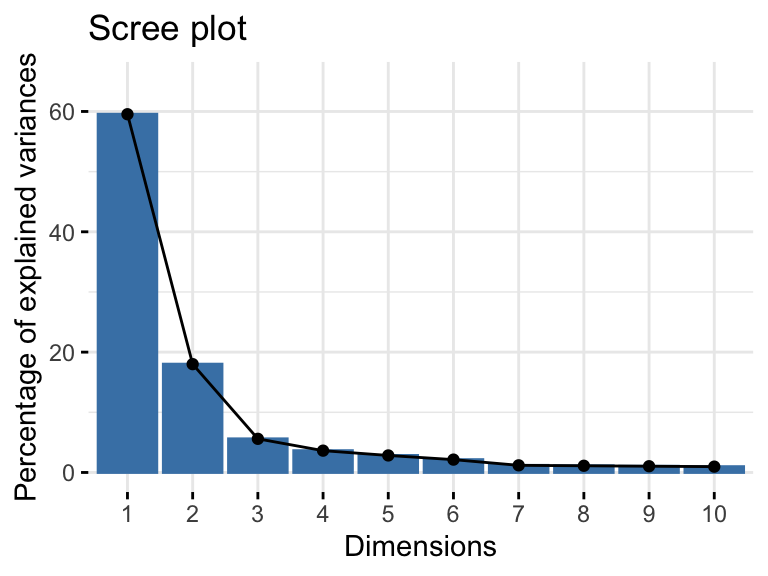

```r
# Scree Plot PCA results
fviz_screeplot(pca, addLabels = TRUE,ylim = c(0, 65))
```

## Default PCA Plot

```r
library(ggplot2)
library(ggfortify)
library(plotly)
library(ggrepel)
```

## Default graph of variables and loading vectors

```r
# Perform PCA
data_unsupervised_scaled <- scale(features, center = TRUE, scale = TRUE)

pca_unsupervised <- prcomp(data_unsupervised_scaled, scale = TRUE)
```

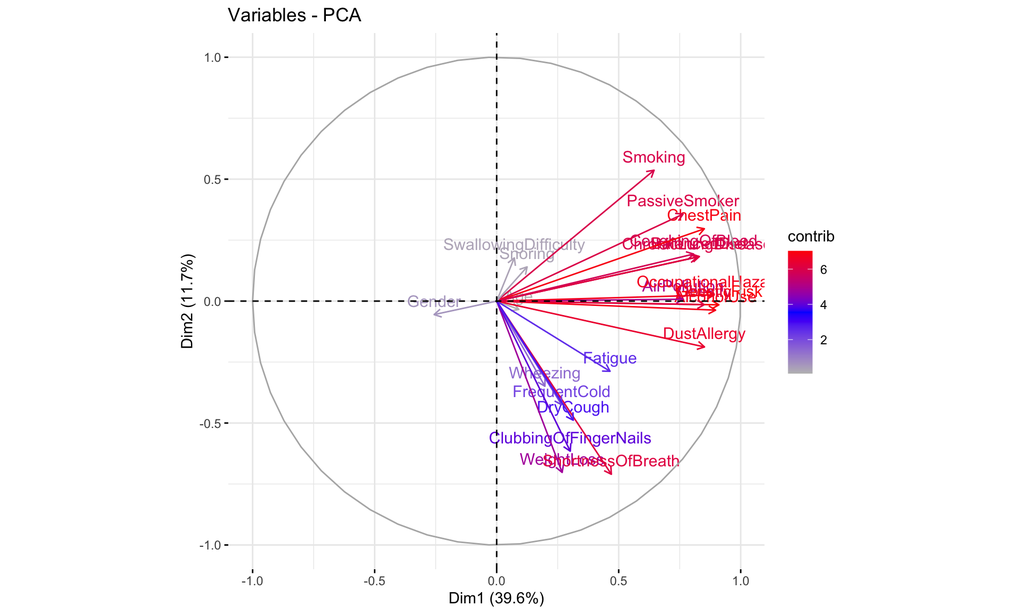

```r
# Plot PCA
fviz_pca_var(pca_unsupervised, col.var = "contrib", gradient.cols = c("gray", "blue", "red"),
             label = "var", ggtheme = theme_minimal())
```

- variables in red have highest contribution to the principal components
- 39.6% of the variation in the dataset is explained in the first dimension
- factors like gender, snoring, and wheezing do not seem to have high contributions here
- passive smoker, smoking, and coughing of blood have high contributions in this plot and are positively correlated with PC1

```r
classes <- data$Level

# unsupervised, so remove level column
lung_cancer <- select(data, -Level)
lung_cancer$PatientID<- as.numeric(lung_cancer$PatientID)
# PCA
pca_data <- prcomp(lung_cancer, scale = TRUE)
pca_data <- data.frame(pca_data$x[, 1:2], classes = classes)

# Create label data
label_data <- data.frame(PC1 = pca_data$PC1, PC2 = pca_data$PC2, label = names(lung_cancer))
```

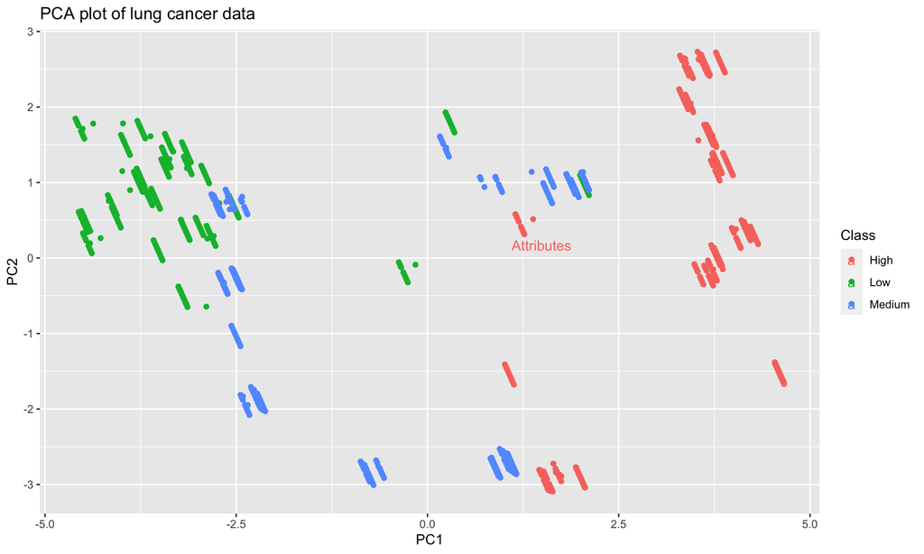

```r
# Plot PCA
ggplot(pca_data, aes(x = PC1, y = PC2, color = classes)) +
  geom_point() +
  geom_text_repel(aes(label = "Attributes")) +
  labs(x = "PC1", y = "PC2", color = "Class") +
  ggtitle("PCA plot of lung cancer data")
```

- green (low) is clustered high in 2nd dimension, while red (high) is clustered high and low in the 1st dimension - medium is also all over the plot, explained by both dimensions

## K-means clustering

Check how balanced the original dataset is:

```r
table(data$Level)
```

```
#>
#>   High    Low Medium
#>    365    303    332
```

- it’s not perfectly balanced, but there should be enough observations of each level for the k-means to work.

```r
# Standardize the data, features has no labels and level column is removed
lung_cluster_std <- scale(features[,-1])
```

```r
# euclidean distances, part of factoextra package
features_data<- dist(lung_cluster_std)
```

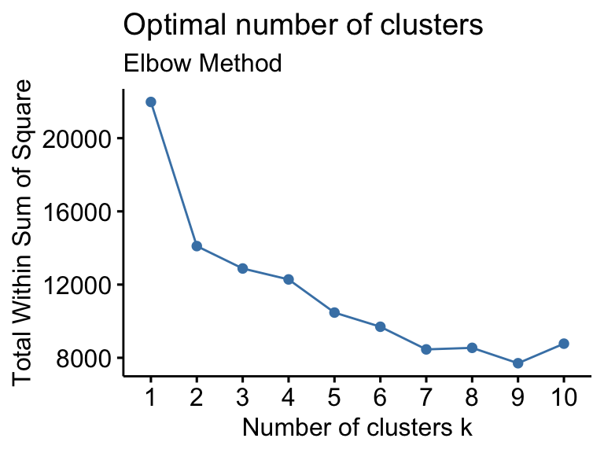

```r
# find optimal number of clusters
# within sum squares metric
fviz_nbclust(lung_cluster_std, kmeans, method = "wss")+
  labs(subtitle = "Elbow Method")
```

```r
# we will use 7 clusters, k = 7
```

```r
# Perform k-means clustering with k=6
km <- kmeans(lung_cluster_std, centers=7, nstart=100)

# View the clustering results
print(km)
```

```
#> K-means clustering with 7 clusters of sizes 234, 100, 80, 221, 128, 167, 70
#>
#> Cluster means:
#>         Gender AirPollution AlcoholUse DustAllergy OccupationalHazards
#> 1  0.434992962   -0.5863020 -1.0596069  -1.3044026          -1.1182694
#> 2 -0.004077079    0.3250592  1.0826275   0.9263780           0.7401063
#> 3  0.148813382    0.2019307  0.1190623   0.3584351           0.1352117
#> 4 -0.072335867   -0.8839399 -0.9262641  -0.5150377          -0.7634627
#> 5 -0.214301462    1.2100451  1.1058818   0.8869375           0.9876980
#> 6 -0.355633587    0.9753544  0.9962511   0.7752289           0.9111274
#> 7 -0.149687041   -0.4840708  0.3848264   0.7821385           0.9569873
#>   GeneticRisk ChronicLungDisease BalancedDiet    Obesity    Smoking
#> 1  -1.0703255         -0.8020287   -0.8202580 -1.0534528 -0.4688575
#> 2   0.5735781          0.2272091   -0.6045344 -0.5011950 -0.9407422
#> 3   0.1974613         -0.1379484    0.5895498  1.1341597 -0.5300689
```

[output cut: 67 more lines]

Visual of K-means

```r
cluster<- km$cluster
rownames(lung_cluster_std)<- paste(data$Level, 1:dim(data)[1], sep = "_")
```

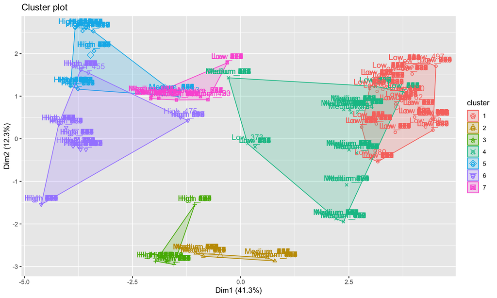

```r
fviz_cluster(list(data= lung_cluster_std, cluster = cluster))
```

```r
table(cluster, data$Level)
```

```
#>
#> cluster High Low Medium
#>       1    0 234      0
#>       2    0   0    100
#>       3   80   0      0
#>       4    0  49    172
#>       5  118   0     10
#>       6  167   0      0
#>       7    0  20     50
```

- Clusters 1, 2, 3, and 6 correctly predict high, low and medium levels
- Clusters 4, 5 and 7 misclassified some obervations
- High level is associated with clusters 3, 5 and 6

```r
# Calculate the mean values of the features within each cluster
cluster_means <- aggregate(features[,-1], by=list(cluster=km$cluster), FUN=mean)

# View the results
print(cluster_means)
```

```
#>   cluster   Gender AirPollution AlcoholUse DustAllergy OccupationalHazards
#> 1       1 1.615385     2.649573   1.786325    2.581197            2.482906
#> 2       2 1.400000     4.500000   7.400000    7.000000            6.400000
#> 3       3 1.475000     4.250000   4.875000    5.875000            5.125000
#> 4       4 1.366516     2.045249   2.135747    4.144796            3.230769
#> 5       5 1.296875     6.296875   7.460938    6.921875            6.921875
#> 6       6 1.227545     5.820359   7.173653    6.700599            6.760479
#> 7       7 1.328571     2.857143   5.571429    6.714286            6.857143
#>   GeneticRisk ChronicLungDisease BalancedDiet  Obesity  Smoking PassiveSmoker
#> 1    2.303419           2.897436     2.739316 2.226496 2.777778      2.649573
#> 2    5.800000           4.800000     3.200000 3.400000 1.600000      2.300000
#> 3    5.000000           4.125000     5.750000 6.875000 2.625000      3.500000
#> 4    2.823529           2.873303     2.687783 3.416290 2.493213      2.769231
#> 5    6.390625           6.296875     6.921875 6.328125 7.539062      6.921875
#> 6    6.940120           6.173653     6.766467 6.820359 6.598802      7.646707
```

[output cut: 17 more lines]

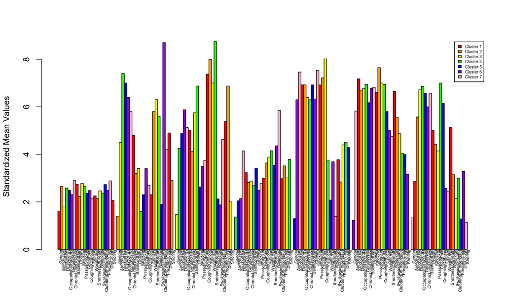

```r
# add labels to the bar plot
text(x = barplot(t(cluster_means[,-1]), beside = TRUE, col = c("red", "orange", "yellow", "green", "blue", "purple", "pink"), ylab = "Standardized Mean Values"),
     labels = colnames(lung_cluster_std),
     y = 0,
     xpd = TRUE,
     srt = 90, adj = c(1,1),
     cex= 0.5)
legend("topright", legend=paste("Cluster", 1:7), fill=c("red", "orange", "yellow", "green", "blue", "purple", "pink"), cex = 0.5)
```

Finding 10 highest features by mean value:

```r
# Calculate mean values for each feature across all clusters
feature_means <- apply(cluster_means[, -1], 2, mean)

# Order means in descending order
ordered_means <- sort(feature_means, decreasing = TRUE)

# Identify top 5 features with highest mean values
top_features <- names(ordered_means)[1:10]

# Print top features
cat("Top 10 features by mean value: \n")
```

```
#> Top 10 features by mean value:
```

```r
cat(top_features, sep = "\n")
```

```
#> DustAllergy
#> OccupationalHazards
#> CoughingOfBlood
#> AlcoholUse
#> GeneticRisk
#> BalancedDiet
#> ShortnessOfBreath
#> Obesity
#> ChestPain
#> ChronicLungDisease
```